# Game of Life

An implementation in JavaScript

2020-05-20

I've made my first implementation of Game of Life using JavaScript. A very rewarding task for a developer aiming to get better. And a delightful one.

This is from the browser rendering:

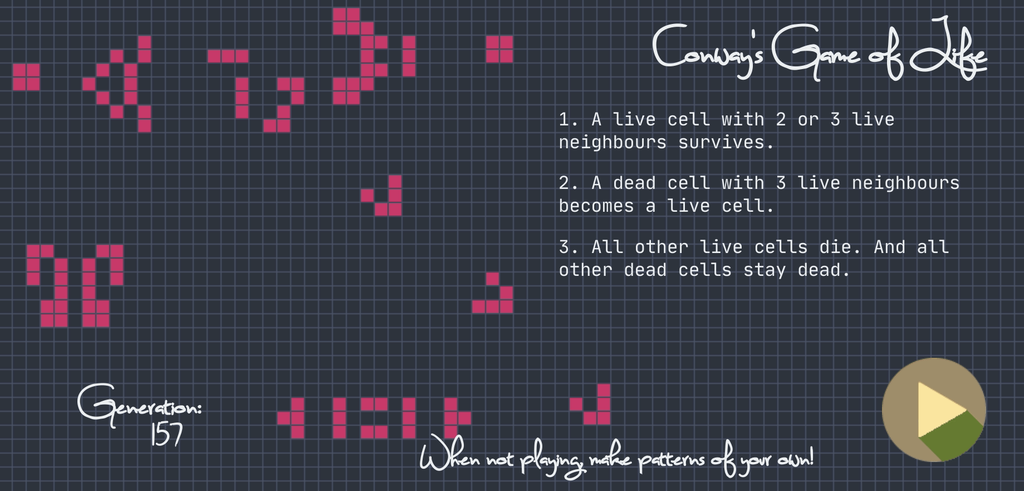

[Source code available at GitHub](https://github.com/bergsans/game-of-life)

This is from the node-js rendering:

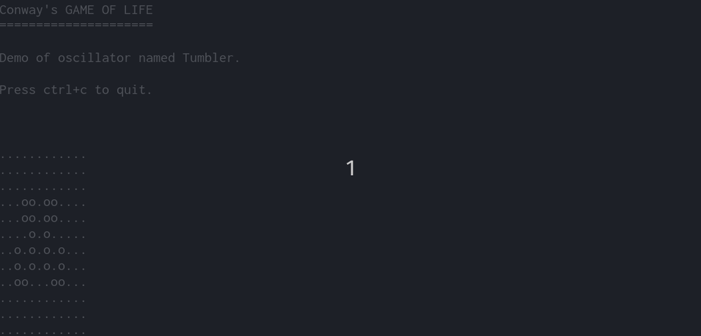

In this post, I will shortly explain the logic related to the implementation, excluding the rendering and the state-management.

[Game of Life](https://en.wikipedia.org/wiki/Conway%27s_Game_of_Life) is a simulation by the late mathematician [John Conway](https://en.wikipedia.org/wiki/John_Horton_Conway) (1937 - 2020). It became known to the public in 1970 as a 'mathematical puzzle' when it appeared in the Scientific American. Game of Life continues to fascinate new generations.

Conway constructed Game of Life as a project, researching [cellular automata](https://en.wikipedia.org/wiki/Cellular_automaton), a field investigating surfaces manifested as grids with a set of cells that each have a finite number of states (true or false, for instance).

A cellular automaton is a 'world' in the sense that given rules, the rules (can) — from generation to generation — change the state of cells over time .

But what *is* Game of Life?

Game of Life is called a zero-player game since you only configure an initial 'board' with alive (and implicitly) dead cells. Given a few simple rules [amazing patterns can emerge](https://www.youtube.com/watch?v=C2vgICfQawE). Game of Life is [Turing complete](https://en.wikipedia.org/wiki/Turing_completeness), meaning it's possible to make patterns that can act as a Turing machine and in theory solve any computation. The universality of the rules has been tested and [machines have been built](https://www.youtube.com/watch?v=8unMqSp0bFY) using them.

What are [the rules](https://en.wikipedia.org/wiki/Conway%27s_Game_of_Life)?

- Any live cell with fewer than two live neighbours dies, as if by underpopulation.
- Any live cell with two or three live neighbours lives on to the next generation.
- Any live cell with more than three live neighbours dies, as if by overpopulation.
- Any dead cell with exactly three live neighbours becomes a live cell, as if by reproduction.

You can also phrase the rules like so:

- Any live cell with two or three live neighbours survives.
- Any dead cell with three live neighbours becomes a live cell.
- All other live cells die in the next generation. Similarly, all other dead cells stay dead.

Game of Life is played on a rectangular grid of square cells. A cell is neighbour with another cell if it is next to it.

Starting from the north we travel clockwise, allowing vertical, horizontal, and diagonal movements.

```javascript
const POSSIBLE_DIRECTIONS = {
  north: [  0, -1 ],
  northEast: [  1, -1 ],
  east:  [  1,  0 ],
  southEast: [  1,  1 ],
  south: [  0,  1 ],
  southWest: [ -1,  1 ],
  west:  [ -1,  0 ],
  northWest: [ -1, -1 ]
};
```

However, I have this object only for declarative reasons. What I want are the values.

For each cell, I need to investigate its neighbour relation and their state. Therefore,

```javascript
const dirs = Object.values(POSSIBLE_DIRECTIONS);
```

Based on all the possible directions, I ask which neighbours are alive?

```javascript
function neighboursAlive(world, x, y) {
  return dirs.reduce(
    (aliveNeighbours, [ diffX, diffY ]) => isNeighbourAlive(
      world,
      x + diffX,
      y + diffY
    )
      ? aliveNeighbours + 1
      : aliveNeighbours
    , 0
  );
}
```

How do we know if a neighbour is alive? In my implementation, the state of a cell - if it is alive or dead - is represented by a boolean value:

```javascript
const ALIVE = true;
const DEAD = false;
```

Given a world, a grid, and a position to look at, I investigate this state by first checking if the position is in range of the grid.

At position 0,0 looking west would mean looking outside the grid. This is a design choice, some implement Game of Life so that looking west from position 0,0 would mean a cell positioned to the far right on the grid. In my implementation, this is outside the tip of the world - in emptiness, and thus `false`.

```javascript
function isInRange(w, h, x, y) {
  return x >= 0 &&
    x < w &&
    y >= 0 &&
    y < h;
}
```

A cell must be in range and be alive to be `true`.

```javascript
function isNeighbourAlive(grid, x, y) {
  return isInRange(
    width(grid),
    height(grid),
    x,
    y
  ) && grid[y][x];
}
```

The `width` and `height` are simple helpers:

```javascript
const height = (grid) => grid.length;
const width = (grid) => grid[0].length;
```

A function (quoted again) provide the answer to the question of how many living neighbours a cell has, starting from 0.

```javascript
function neighboursAlive(world, x, y) {
  return dirs.reduce(
    (aliveNeighbours, [ diffX, diffY ]) => isNeighbourAlive(
      world,
      x + diffX,
      y + diffY
    )
      ? aliveNeighbours + 1
      : aliveNeighbours
    , 0
  );
}
```

What is important is the transition from a state to the next. If we have a grid, a world, filled with cells — each either alive or dead, `true` or `false` — we determine the next state of the 'world' by determining the next state of each cell. The world is nothing but the totality of all cells, and their status.

```javascript
function nextState(grid) {
  return grid.map(
    (row, y) => row.map(
      (cell, x) => nextCellState(cell, neighboursAlive(grid, x, y))
    )
  );
}
```

I choose to concentrate on next generation living cells. Based on the current state — alive and dead — three possible states leading to life in the next generation emerge:

```javascript
const SPECIAL_STATES = [
  {
    ssState: DEAD,
    ssNeighboursAlive: 3,
  },
  {
    ssState: ALIVE,
    ssNeighboursAlive: 2,
  },
  {
    ssState: ALIVE,
    ssNeighboursAlive: 3,
  }
];
```

All other possible states lead to death, are `false`.

Therefore, given the current state and the number of alive neighbours, I check if one of the three special cases above is `true`. Otherwise, I conclude, following the rules of Game of Life, the cell at hand will die (and if it dies it's status is `false`).

```javascript
function nextCellState(state, neighboursAlive) {
  return SPECIAL_STATES.some(
    ({ ssState, ssNeighboursAlive }) => ssState === state &&
      ssNeighboursAlive === neighboursAlive
  );
}
```

This is my implementation of the logic. I used a functional programming-like approach, as you see. The performance is not the best, but it's good enough given a small grid.

The logic only handles the manipulation of state transition in a cell, given the state of its neighbours, moving from one generation to the next.

In my view, what we do with this - how we iterate numerous generations, the 'game loop' - should not be part of the logic.

In my demos, I deliberately slowed down the transition so the 'evolution' would appear pleasant for the eye.

# Adhoc refactoring

In my implementation, I have a function labeled `neighboursAlive` that takes a world — a grid with cells — and a position x,y, and returns how many alive neighbours this cell has.

I am not satisfied with my solution as my intention was to write readable code.

My implementation for this particular problem:

```javascript
function neighboursAlive(world, x, y) {
  return dirs.reduce(
    (aliveNeighbours, [ diffX, diffY ]) => isNeighbourAlive(
      world,
      x + diffX,
      y + diffY)
        ? aliveNeighbours + 1
        : aliveNeighbours
    , 0
    );
}
```

From the outside the label is declarative, but in the situation of solving the problem (or when refactoring) the code itself is not very declarative. The use of `reduce` to avoid an assignment could be called a Hollywood version of functional programming.

```javascript
function neighboursAlive(world, x, y) {
  let sum = 0;
  for(const direction of directions) {
    const [ diffX, diffY ] = direction;
    if(isNeighbourAlive(world,  x + diffX, y + diffY)) {
      sum += 1;
    }
  }
  return sum;
}
```

This function is just as pure. As someone said, what's important in functional programming are values being 'eventually immutable'.

The label `sum` can't possibly be mutated in any way by some side-effect. It doesn't matter what other values mutate outside of the function.

[About](https://bergsans.github.io/about) | [Archive](https://bergsans.github.io/essays)